# Movies Dataset

Olaleye Damilare

9/5/2019

```r
library(tidyverse)
movies <- read_csv("http://www-math.bgsu.edu/~albert/3430/top100movies.csv")
```

1.) Currently Runtime is a character variable. Create a new numeric variable Rtime in the data frame by typing

```r
movies$Rtime <- as.numeric(gsub('min', '',       movies$Runtime))
```

2.) List the data (all variables) for the movies that have been made since 2011.

```r
movies[movies$Year > 2011, ]
```

```
## # A tibble: 6 x 10
##    Rank Title  Year Rated Runtime Country Metascore imdbRating imdbVotes
##   <dbl> <chr> <dbl> <chr> <chr>   <chr>       <dbl>      <dbl>     <dbl>
## 1    29 Inte…  2014 PG-13 169 min USA, U…        74        8.7    645963
## 2    40 Whip…  2014 R     107 min USA            88        8.6    244998
## 3    48 Insi…  2015 PG    94 min  USA            93        8.7     44496
## 4    59 Djan…  2012 R     165 min USA            81        8.5    789525
## 5    61 The …  2012 PG-13 165 min USA, UK        78        8.5    975322
## 6    85 Mad …  2015 R     120 min Austra…        89        8.5    226488
## # … with 1 more variable: Rtime <dbl>
```

3.) By using R operations, find the movie with the longest running time, and find the movie with the shortest running time.

```r
movies[movies$Rtime == max(movies$Rtime, na.rm = TRUE), ]
```

```
## # A tibble: 2 x 10
##    Rank Title  Year Rated Runtime Country Metascore imdbRating imdbVotes
##   <dbl> <chr> <dbl> <chr> <chr>   <chr>       <dbl>      <dbl>     <dbl>
## 1    75 Once…  1984 R     229 min Italy,…        NA        8.4    192901
## 2    NA <NA>     NA <NA>  <NA>    <NA>           NA       NA          NA
## # … with 1 more variable: Rtime <dbl>
```

```r
movies[movies$Rtime == min(movies$Rtime, na.rm = TRUE), ]
```

```
## # A tibble: 2 x 10
##    Rank Title  Year Rated Runtime Country Metascore imdbRating imdbVotes
##   <dbl> <chr> <dbl> <chr> <chr>   <chr>       <dbl>      <dbl>     <dbl>
## 1    NA <NA>     NA <NA>  <NA>    <NA>           NA       NA          NA
## 2    96 The …  1921 NOT … 68 min  USA            NA        8.4     54695
## # … with 1 more variable: Rtime <dbl>
```

4.) List only the titles for the movies rated G.

```r
rating <- movies[movies$Rated == "G",]
rating
```

```
## # A tibble: 5 x 10
##    Rank Title  Year Rated Runtime Country Metascore imdbRating imdbVotes
##   <dbl> <chr> <dbl> <chr> <chr>   <chr>       <dbl>      <dbl>     <dbl>
## 1    39 Mode…  1936 G     87 min  USA            96        8.6    119542
## 2    54 The …  1994 G     89 min  USA            83        8.5    537320
## 3    62 "WAL…  2008 G     98 min  USA            94        8.4    606826
## 4    76 Toy …  2010 G     103 min USA            92        8.4    457959
## 5    95 2001…  1968 G     160 min USA, UK        86        8.3    367502
## # … with 1 more variable: Rtime <dbl>
```

```r
roundimdb <- round(movies$imdbVotes/100000, 1) * 100000
roundimdb
```

```
##   [1] 1480000 1010000  680000 1450000 1150000  380000  750000  440000
##   [9] 1050000 1160000 1080000  690000 1050000 1260000  600000  950000
##  [17]  640000 1050000  760000  200000  470000  880000  750000  650000
##  [25]  240000  350000  630000  190000  650000  350000  750000  680000
##  [33]  350000   90000  570000  370000  280000  410000  120000  240000
##  [41]  650000  660000  430000  740000  750000  850000  400000   40000
##  [49]  620000  120000  310000  720000  490000  540000  230000  110000
##  [57]      NA  530000  790000  100000  980000  610000  730000  110000
##  [65]  430000  270000  200000  220000  310000  190000  150000   90000
##  [73]  550000       0  190000  460000  570000   50000  640000  480000
##  [81]   90000  440000  500000  190000  230000  170000  580000  420000
##  [89]  150000   80000  240000  130000  340000      NA  370000   50000
##  [97]  130000   90000  370000   70000
```

6.) Construct a histogram of the Rtime variable. Based on the graph, write a short paragraph about the distribution of run times, talking about shape, “average”, and spread, and any unusual features.

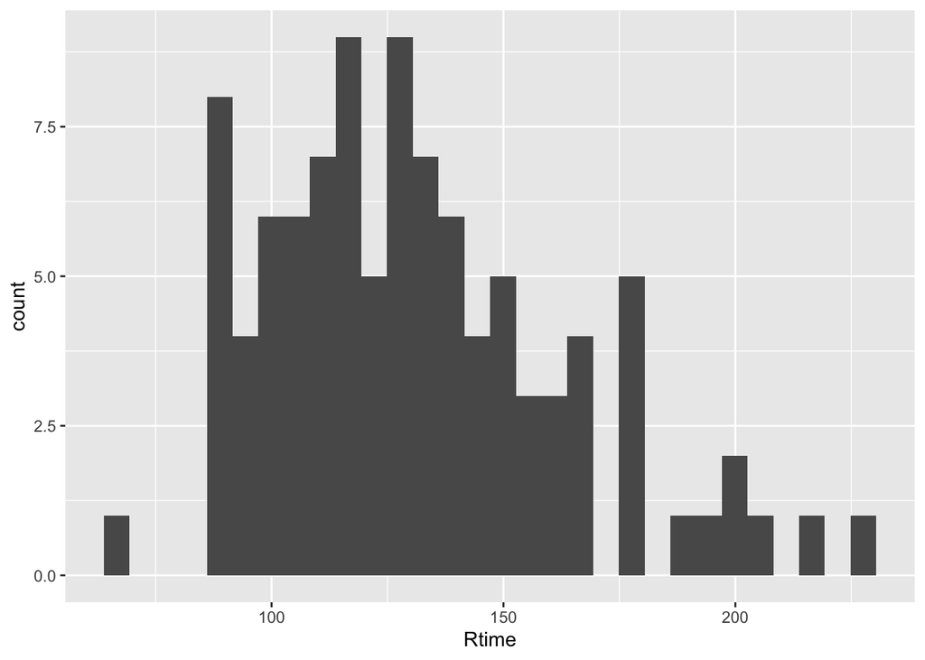

```r
ggplot(movies, aes(Rtime)) + geom_histogram()
```

Most movies are of length 90 to 140 minutes that is, about an hour and a half to little over two hours. In my opinion this is the best length for a movie to play out the story and to also give the audience a great experience that isn’t too short or too long which could potentially wear out the audience. Only a handful of the movies are of length more than 3 hours.

7.) Construct a frequency table of the Rated variable. What is the most common rating (the mode)? What fraction of the movies had this rating?

```r
table(movies$Rated)
```

```
##
##  APPROVED         G       N/A NOT RATED    PASSED        PG     PG-13
##        11         5         3         7         2        12        12
##         R   UNRATED         X
##        44         3         1
```

44% of the movies were R rated. It makes sense that most of the movies are R rated because the percentage of adults that goes out to watch movies are usually higher than that of kids, and R rated movies are usually for adults.

8.) Construct a frequency table of the Year variable, and use a barplot to graph these frequencies. Generally, these top 100 movies tended to be made during what years?

```r
(YearTable <- table(movies$Year))
```

```
##
## 1921 1931 1936 1940 1941 1942 1944 1946 1948 1950 1952 1954 1957 1958 1959
##    1    2    1    1    1    1    1    1    1    3    1    2    3    1    1
## 1960 1962 1964 1965 1966 1968 1971 1972 1973 1974 1975 1976 1977 1979 1980
##    1    2    1    1    1    2    1    1    1    1    2    1    1    2    2
## 1981 1983 1984 1985 1986 1987 1988 1990 1991 1992 1993 1994 1995 1997 1998
##    2    1    2    1    1    1    1    1    2    1    1    5    3    3    2
## 1999 2000 2001 2002 2003 2004 2005 2006 2008 2009 2010 2011 2012 2014 2015
##    4    3    2    3    2    1    1    4    2    1    2    1    2    2    2
```

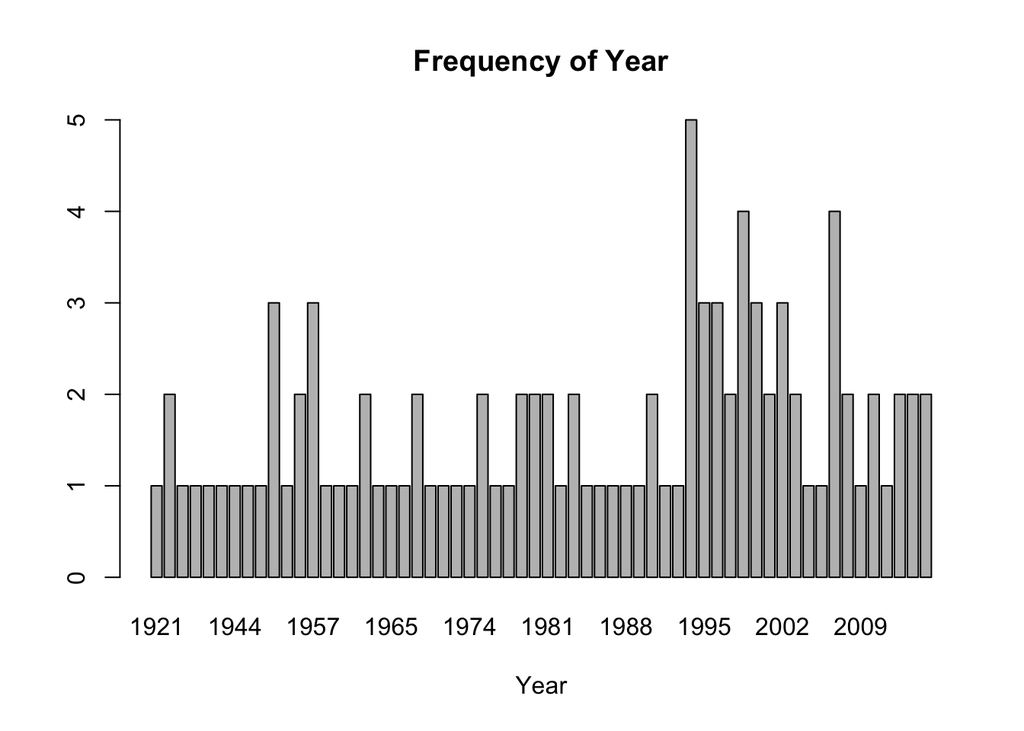

```r
barplot(YearTable, main = "Frequency of Year", xlab = "Year" )
```

In between the year 1990 and 2000, we can see that there were higher numbers of top 100 movies than any other time period.

```r
RtimeCut <- cut(movies$Rtime, 50)
RtimeCut
```

```
##   [1] (139,142]   (174,177]   (197,200]   (152,155]   (152,155]
##   [6] (93.8,97]   (194,197]   (158,161]   (200,203]   (139,142]
##  [11] (177,181]   (123,126]   (139,142]   (145,148]   (132,136]
##  [16] (177,181]   (145,148]   (136,139]   (120,123]   (206,210]
##  [21] (129,132]   (126,129]   (116,120]   (103,107]   (129,132]
##  [26] (113,116]   (110,113]   (174,177]   (168,171]   (100,103]
##  [31] (168,171]   (116,120]   (123,126]   (84.1,87.3] (113,116]
##  [36] (107,110]   (110,113]   (110,113]   (84.1,87.3] (107,110]
##  [41] (136,139]   (187,190]   (148,152]   (110,113]   (148,152]
##  [46] (155,158]   (152,155]   (93.8,97]   (113,116]   (110,113]
##  [51] (93.8,97]   (129,132]   (116,120]   (87.3,90.5] (136,139]
##  [56] (123,126]   (100,103]   (145,148]   (165,168]   (87.3,90.5]
##  [61] (165,168]   (97,100]    (120,123]   (87.3,90.5] (136,139]
##  [66] (116,120]   (136,139]   (126,129]   (120,123]   (132,136]
##  [71] (148,152]   (97,100]    (132,136]   (87.3,90.5] (226,229]
##  [76] (100,103]   (97,100]    (113,116]   (174,177]   (136,139]
##  [81] (107,110]   (110,113]   (100,103]   (126,129]   (120,123]
##  [86] (213,216]   (107,110]   (113,116]   (126,129]   (90.5,93.8]
##  [91] (158,161]   (100,103]   (90.5,93.8] <NA>        (158,161]
##  [96] (67.8,71.2] (129,132]   (87.3,90.5] (136,139]   (136,139]
## 50 Levels: (67.8,71.2] (71.2,74.4] (74.4,77.7] (77.7,80.9] ... (226,229]
```

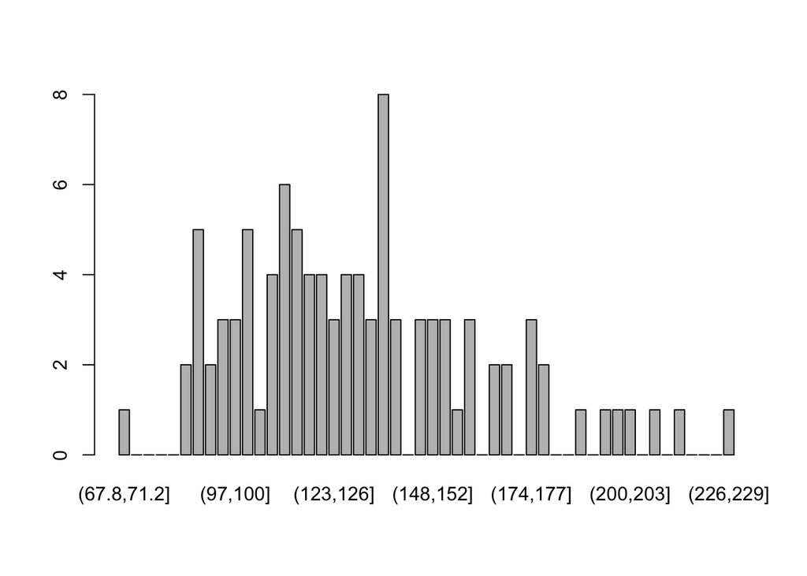

```r
plot(RtimeCut)
```

10.) Construct a scatterplot of the two measures Metascore and imdbRating. What pattern do you see in this plot, and what does that say about the relationship between these two variables. Are you surprised? Explain.

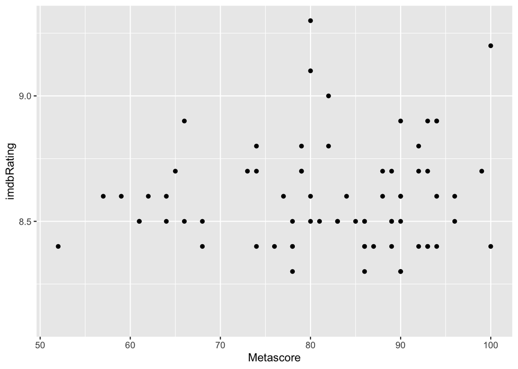

```r
ggplot(movies, aes(Metascore, imdbRating)) + geom_point()
```

In the scatterplot we can see that the Metascore for the imdbRating is crowed between 70 to 95.